# Data cleanup and summary statistics with R

Jasleen Grewal

2019-02-21

# Getting started

This tutorial assumes you know how to load data into an RStudio session, view a dataframe and explore columns/rows of a dataframe in R. Knowing how to visualize data as scatterplots will also be helpful, though not essential.

We will be using two packages - reshape2 and [ggpubr](https://cran.r-project.org/web/packages/ggpubr/index.html).  
- reshape2 is a package with 2 main functions, `melt` and `dcast`. It is helpful for flexibly reshaping your data.  
- ggpubr is a graphing package, that lets you create publication ready ggplots, and automatically add significance levels to your figures.  
Let us also load up ggplot2 into our current environment, just in case we want to make pretty plots.

```r
# If you don't have a package installed already install.packages('packagename')
# Otherwise, load it into the environment
library(ggplot2)
library(ggpubr)
library(reshape2)
```

R provides excellent support for statistical analysis. The data we will be working with is cell-line expression data from the LINCS1000 dataset. I have adapted this dataset for our use, which is available at the same spot you found this tutorial. You can also download the original data from [here](http://lincsportal.ccs.miami.edu/datasets/view/LDS-1530#downloaddataset).

## Cleaning my data

```r
## Load the data
data_df <- read.table("data_sp_scaled.txt", sep = "\t", stringsAsFactors = F, header = T)
## and the covariate information
metadata_df <- read.table("metadata.txt", sep = "\t", stringsAsFactors = F, header = T)
```

As always, let us start by figuring out what we are working with. The `dim()` function prints the dimensions of a dataframe, and `head()` function shows the first 6 rows of a dataframe. You can also print only the row-count (or column-count) with the commands `nrow()` and `ncol()`.  
The command `dim(data_df)` tells us that the data has 35 rows and 33842 columns. Similarly, the row count and column count values for the metadata dataframe, `metadata_df`, are 35, 5, respectively.

Notice that if we try to print the first 6 rows of `data_df`, the output is immense. Thus, instead of `head(data_df)`, we will print the first 6 rows, with the first 10 columns. We can select these columns with `data_df[,1:10]`.

|  | TSPAN6 | TNMD | DPM1 | SCYL3 | C1orf112 | FGR | CFH | FUCA2 | GCLC | NFYA |
| --- | --- | --- | --- | --- | --- | --- | --- | --- | --- | --- |
| HCC1806 | 3.505880 | 0 | NA | NA | 3.534551 | NA | 2.8251175 | 5.727614 | NA | 4.600950 |
| MCF10A | 4.027427 | 0 | 5.549405 | 2.482252 | 3.963324 | 0.0000000 | 5.2812262 | 5.292880 | 6.521847 | 4.172004 |
| SKBR3 | 2.684550 | 0 | 6.747064 | 3.199656 | 4.189142 | 0.1014213 | 0.0096204 | 5.240616 | 4.322539 | 3.518300 |
| HS578T | NA | 0 | NA | 1.424340 | 3.363768 | 0.0369093 | 5.2759113 | 5.841921 | 3.851815 | 4.461398 |
| MDAMB231 | 4.287758 | NA | 5.693864 | 2.217807 | 4.619957 | 0.0000000 | 0.9724045 | 5.677292 | 4.046207 | 5.442562 |
| BT20 | 3.335776 | 0 | 6.602087 | 2.648148 | 3.904788 | 0.0000000 | 0.1888233 | 4.781958 | 5.623793 | 4.138710 |

The column names correspond to genes, and the rows represent samples. These sample names correspond to the column `cl_id` in `metadata_df` (can you quickly verify this using `head`?).

We can also quickly ensure we don’t have random unexpected values (such as characters or alphabets where we expect numbers) using the query `is.numeric`. You can quickly check what this function does, by entering `?is.numeric` in your R prompt.

```r
table(sapply(data_df, is.numeric))
```

```
##
##  TRUE
## 33842
```

Looks like all our columns are numeric!

Take a quick look at the output from the `head()` function a couple of lines ago. It looks like we have some missing values in our data! Before we try and figure out a fix for this, let us calculate how many genes have missing values, or if the problem is only in a single sample.  
R has a handy command, `complete.cases`, for checking if there are any rows containing missing values. It returns a TRUE/FALSE value for every row. We can summarize the results of this **list** in tabular form, using the function `table()`.

```r
table(complete.cases(data_df))
```

| Var1 | Freq |
| --- | --- |
| FALSE | 5 |
| TRUE | 30 |

It appears 5 samples have atleast 1 gene with a missing value. We can redo this test for the genes, after **transposing** our data. This is done using the function `t()`.

```r
table(complete.cases(t(data_df)))
```

| Var1 | Freq |
| --- | --- |
| FALSE | 18941 |
| TRUE | 14901 |

## Dealing with missing data

Over 50% of the genes across 5 samples are missing. We can deal with this either using imputation strategies, or by discarding the problematic samples. As imputation strategies are an entire discussion by themselves, we will *not* into dive into them today (additional resources available at end of tutorial). Instead, we will take the easy way out and remove the samples with NAs. Good thing we have already covered a quick way to unselect these samples!.

```r
data_df_clean <- data_df[complete.cases(data_df), ]
```

> If you were perusing the previous tutorial, you would have noticed us using `na.omit` to find rows in a dataframe that contain any NA value (in any column). These two commands are functionally the same, but complete.cases can be used on a subset of columns instead of the entire dataframe as well. For example, if we wanted only to remove the samples where 1 or more of certain genes were missing, we could have chosen them with data_df[complete.cases(data_df[,c(“myFavGene1”, “myFavGene2”,….,“myfavGeneN”)]), ]. Don’t forget the comma after the row-selection!

After this, we have 30 samples and 33842 genes. We can do a quick ‘smell-test’ on this data, by using the dataframe function `summary()`. This function calculates summary statistics for each column in the dataframe. We can transpose the dataframe so that the samples become columns (instead of rows).

```r
summary(t(data_df_clean))
```

|  | BT20 | MCF7 | PDX1258 | PDX1328 | BT549 | HCC38 | HCC70 | MDAMB134 | MDAMB157 | MDAMB361 | MDAMB436 | MDAMB453 | MDAMB468 | PDXHCI002 | HCC1143 | HCC1395 | HCC1419 | HCC1500 | HCC1937 | HCC1954 | CAL120 | CAL51 | CAL851 | SUM149 | SUM159 | SUM1315 | T47D | CAMA1 | HME1 | … |
| --- | --- | --- | --- | --- | --- | --- | --- | --- | --- | --- | --- | --- | --- | --- | --- | --- | --- | --- | --- | --- | --- | --- | --- | --- | --- | --- | --- | --- | --- | --- |
|  | Min. : 0.0000 | Min. : 0.0000 | Min. : 0.0000 | Min. : 1.000 | Min. : 0.0000 | Min. : 0.0000 | Min. : 0.0000 | Min. : 0.0000 | Min. : 0.0000 | Min. : 0.0000 | Min. : 0.0000 | Min. : 0.0000 | Min. : 0.000 | Min. : 0.0000 | Min. : 0.0000 | Min. : 0.0000 | Min. : 0.0000 | Min. : 0.0000 | Min. : 0.0000 | Min. : 0.0000 | Min. : 0.0000 | Min. : 0.0000 | Min. : 0.0000 | Min. : 0.0000 | Min. : 0.0000 | Min. : 0.0000 | Min. : 0.0000 | Min. : 0.0000 | Min. : 0.0000 | … |
|  | 1st Qu.: 0.0000 | 1st Qu.: 0.0000 | 1st Qu.: 0.0000 | 1st Qu.: 1.000 | 1st Qu.: 0.0000 | 1st Qu.: 0.0000 | 1st Qu.: 0.0000 | 1st Qu.: 0.0000 | 1st Qu.: 0.0000 | 1st Qu.: 0.0000 | 1st Qu.: 0.0000 | 1st Qu.: 0.0000 | 1st Qu.: 0.000 | 1st Qu.: 0.0000 | 1st Qu.: 0.0000 | 1st Qu.: 0.0000 | 1st Qu.: 0.0000 | 1st Qu.: 0.0000 | 1st Qu.: 0.0000 | 1st Qu.: 0.0000 | 1st Qu.: 0.0000 | 1st Qu.: 0.0000 | 1st Qu.: 0.0000 | 1st Qu.: 0.0000 | 1st Qu.: 0.0000 | 1st Qu.: 0.0000 | 1st Qu.: 0.0000 | 1st Qu.: 0.0000 | 1st Qu.: 0.0000 | … |
|  | Median : 0.1565 | Median : 0.2083 | Median : 0.3089 | Median : 1.123 | Median : 0.1346 | Median : 0.2004 | Median : 0.1219 | Median : 0.4786 | Median : 0.3232 | Median : 0.2085 | Median : 0.2637 | Median : 0.1186 | Median : 0.204 | Median : 0.1926 | Median : 0.1836 | Median : 0.1885 | Median : 0.1543 | Median : 0.1977 | Median : 0.2719 | Median : 0.2176 | Median : 0.1677 | Median : 0.1725 | Median : 0.2389 | Median : 0.1493 | Median : 0.1041 | Median : 0.1418 | Median : 0.2078 | Median : 0.1108 | Median : 0.1323 | … |
|  | Mean : 1.6150 | Mean : 1.6330 | Mean : 1.7137 | Mean : 3.433 | Mean : 1.5792 | Mean : 1.6433 | Mean : 1.6028 | Mean : 1.7914 | Mean : 1.7008 | Mean : 1.6365 | Mean : 1.6796 | Mean : 1.5859 | Mean : 1.670 | Mean : 1.6045 | Mean : 1.6385 | Mean : 1.6241 | Mean : 1.5863 | Mean : 1.6684 | Mean : 1.7110 | Mean : 1.6560 | Mean : 1.6060 | Mean : 1.6329 | Mean : 1.6847 | Mean : 1.6150 | Mean : 1.5660 | Mean : 1.5528 | Mean : 1.6730 | Mean : 1.6005 | Mean : 1.5523 | … |
|  | 3rd Qu.: 3.2142 | 3rd Qu.: 3.2164 | 3rd Qu.: 3.2897 | 3rd Qu.: 3.648 | 3rd Qu.: 3.0660 | 3rd Qu.: 3.1915 | 3rd Qu.: 3.1620 | 3rd Qu.: 3.4679 | 3rd Qu.: 3.2967 | 3rd Qu.: 3.2017 | 3rd Qu.: 3.2644 | 3rd Qu.: 3.1528 | 3rd Qu.: 3.322 | 3rd Qu.: 3.1102 | 3rd Qu.: 3.1878 | 3rd Qu.: 3.1407 | 3rd Qu.: 3.0975 | 3rd Qu.: 3.3240 | 3rd Qu.: 3.3607 | 3rd Qu.: 3.2790 | 3rd Qu.: 3.1178 | 3rd Qu.: 3.2700 | 3rd Qu.: 3.3469 | 3rd Qu.: 3.1577 | 3rd Qu.: 3.1224 | 3rd Qu.: 3.0169 | 3rd Qu.: 3.3095 | 3rd Qu.: 3.2538 | 3rd Qu.: 3.0697 | … |
|  | Max. :13.9749 | Max. :13.5385 | Max. :400.7026 | Max. :310.614 | Max. :12.7921 | Max. :12.9747 | Max. :13.5201 | Max. :13.7050 | Max. :13.4885 | Max. :13.5720 | Max. :13.4842 | Max. :13.4478 | Max. :13.215 | Max. :13.4067 | Max. :13.3953 | Max. :13.2711 | Max. :14.2527 | Max. :13.9911 | Max. :12.8188 | Max. :13.2294 | Max. :12.5078 | Max. :12.8472 | Max. :13.3497 | Max. :13.9438 | Max. :13.1575 | Max. :13.2789 | Max. :13.9904 | Max. :13.7174 | Max. :12.5431 | … |

Well, its still hard to read! Enter ggplot! However, we need to set up our data such that we can pass in a column with the sample name, and a column with the values being plotted.

```r
data_compact_df = melt(t(data_df_clean))
colnames(data_compact_df) = c("Gene", "Sample", "Expression")
```

## Dealing with outliers

ggplot has a handy geom_object (remember these from the ggplot tutorial?) for summary statistics. The `stat_summary()` (or `geom_summary()`) method allows us to plot a pointrange plot showing the mean and 2 x standard deviation.

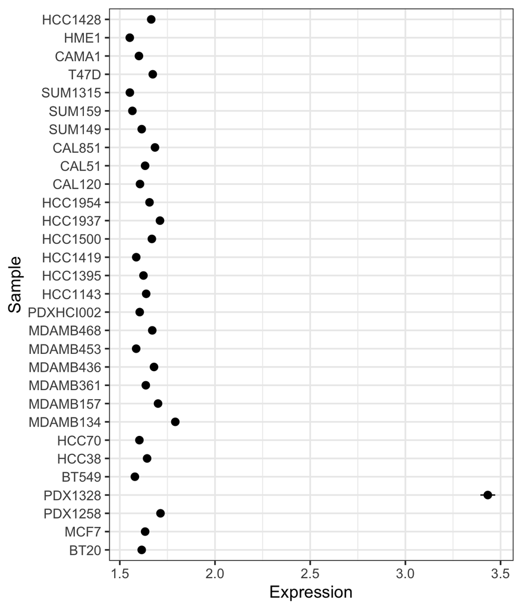

```r
## stat_summary() defaults to the categories defined on the x axis, and summarizes
## the numeric spread on the y-axis We use coord_flip() to switch the categories
## to the y-axis, to improve readability
ggplot(data_compact_df, aes(x = Sample, y = Expression)) + stat_summary() + theme_bw(base_size = 14) +
    coord_flip()
```

```r
## stat_summary with 1 Standard Deviation around mean
ggplot(data_compact_df, aes(x = Sample, y = Expression)) + stat_summary(fun.args = list(mult = 1)) +
    theme_bw(base_size = 14) + coord_flip()
```

[output not shown]

**Segue**: Another ggplot method is `stat_smooth()` (or `geom_smooth()`). This is helpful for plotting a line of best fit on your data. When you may want to compare this with a standard straight line, `geom_abline` is [quite helpful](https://www.rdocumentation.org/packages/ggplot2/versions/1.0.1/topics/geom_abline).

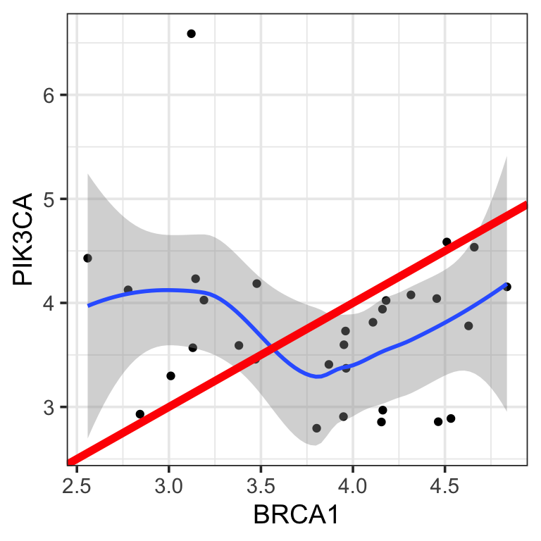

```r
## geom_point to visualize the scatterplot stat_smooth to fit the blue line with
## confidence intervals in grey geom_abline fits an x=y line by default
## (intercept=0, slope=1).
ggplot(data_df_clean, aes(x = BRCA1, y = PIK3CA)) + geom_point() + stat_smooth() +
    geom_abline(colour = "red", size = 2) + theme_bw(base_size = 14)
```

**End of Segue**: Looking back at our stat_summary figure, we have an anomalous sample! The sample `PDX1328` has readings that lie extremely outside the range of the rest of the samples. We can see this more clearly with a boxplot version of the datapoints, plotted using `geom_boxplot()`.

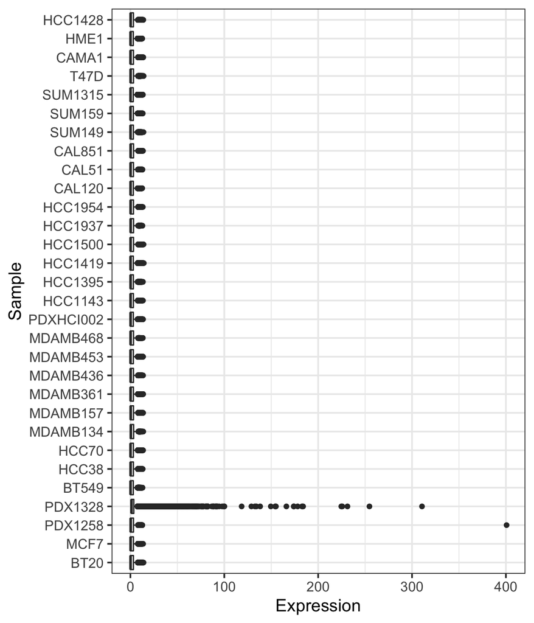

```r
ggplot(data_compact_df, aes(x = Sample, y = Expression)) + geom_boxplot() + theme_bw(base_size = 14) +
    coord_flip()
```

Could we have made this detection analytical? We can calculate the Z-score of each observation. A Z-score is a standardized score, which tells you how many standard deviations away from the mean a data-point is. We can calculate the score using the `scale` function, which is applied to each column by default.

```r
z_data = scale(data_df_clean, center = TRUE, scale = TRUE)
z_data_avgSample = rowMeans(z_data)
```

Let us see which sample has the maximum z-score.

```r
print(sort(z_data_avgSample))
```

|  | x |
| --- | --- |
| HME1 | -0.2219838 |
| SUM159 | -0.1999847 |
| HCC70 | -0.1934084 |
| SUM1315 | -0.1893011 |
| BT549 | -0.1768763 |
| SUM149 | -0.1566986 |
| HCC1419 | -0.1534749 |
| MDAMB453 | -0.1447130 |
| CAMA1 | -0.1394069 |
| HCC1143 | -0.1391422 |
| PDXHCI002 | -0.1363119 |
| CAL120 | -0.1353164 |
| BT20 | -0.1281040 |
| MDAMB361 | -0.1168243 |
| HCC1395 | -0.1133929 |
| HCC38 | -0.1064774 |
| HCC1954 | -0.0957087 |
| MCF7 | -0.0944671 |
| CAL51 | -0.0903028 |
| CAL851 | -0.0835159 |
| MDAMB468 | -0.0716014 |
| HCC1428 | -0.0480493 |
| T47D | -0.0476032 |
| HCC1500 | -0.0466890 |
| MDAMB436 | -0.0288659 |
| HCC1937 | -0.0228481 |
| PDX1258 | -0.0215070 |
| MDAMB157 | 0.0151131 |
| MDAMB134 | 0.1772559 |
| PDX1328 | 2.9102061 |

We can remove the outlier sample using the following command (note that we are making changes to the sample x gene dataframe, not the melted version).

```r
data_df_clean2 = data_df_clean[!(rownames(data_df_clean) %in% c("PDX1328")), ]
```

Alright, so what does the data look like after that?

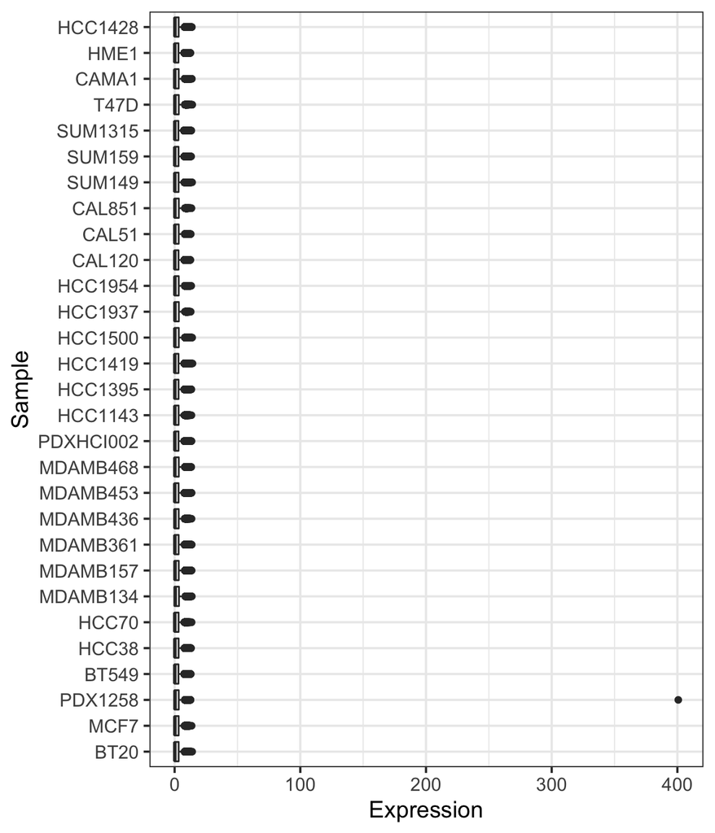

```r
# First we melt our data
data_compact_df = melt(t(data_df_clean2))
colnames(data_compact_df) = c("Gene", "Sample", "Expression")
# Then we plot it
ggplot(data_compact_df, aes(x = Sample, y = Expression)) + geom_boxplot() + theme_bw(base_size = 14) +
    coord_flip()
```

> Also note that while this was easy to do for a small set of samples, you may not be able to visually identify outliers in large datasets. You can calculate z-scores for each sample, and identify samples that lie a few deviations away. You can generate PCA decompositions of your data, and plot the first 2 principal components. If you see a sample sitting further away from the rest, that’s an outlier! There are also more sophisticated approaches for dealing with outliers, [explained nicely at this blogpost](https://datascienceplus.com/outlier-detection-and-treatment-with-r/)

It looks like `PDX1258` has an outlier gene. We can easily print out the gene from our melted dataframe, with the command `data_compact_df[data_compact_df$Expression > 300, "Gene"]`. This returns TSPAN6. We can either remove this gene entirely, or replace it with the mean value. Sample metadata information can come in handy at this point. Let us see what information the metadata dataframe can provide:

```r
print(metadata_df)
```

| cl_id | cl_provider_name | cl_provider_catalog_id | cl_cell_type | cl_disease_detail |
| --- | --- | --- | --- | --- |
| CAL51 | Leibniz Institute | ACC-302 | epithelial-like | breast carcinoma |
| MCF7 | ATCC | HTB-22 | epithelial | breast adenocarcinoma |
| HME1 | ATCC | CRL-4010 | epithelial | normal |
| SKBR3 | ATCC | HTB-30 | epithelial | breast adenocarcinoma |
| MDAMB231 | ATCC | HTB-26 | epithelial | breast adenocarcinoma |
| BT20 | ATCC | HTB-19 |  | breast ductal carcinoma |
| BT549 | ATCC | HTB-122 |  | breast ductal carcinoma |
| CAMA1 | ATCC | HTB-21 |  | breast adenocarcinoma |
| HC1143 | ATCC | CRL-2321 |  | breast ductal carcinoma |
| HCC1395 | ATCC | CRL-2324 |  | breast ductal carcinoma |
| HCC1419 | ATCC | CRL-2326 |  | breast ductal carcinoma |
| HCC1428 | ATCC | CRL-2327 |  | breast adenocarcinoma |
| HCC1806 | ATCC | CRL-2335 |  | squamous cell carcinoma |
| HCC1937 | ATCC | CRL-2336 |  | breast ductal carcinoma |
| HCC1954 | ATCC | CRL-2338 |  | breast ductal carcinoma |
| HCC38 | ATCC | CRL-2314 |  | breast ductal carcinoma |
| HCC70 | ATCC | CRL-2315 |  | breast ductal carcinoma |
| HS578T | ATCC | HTB-126 |  | breast ductal carcinoma |
| MDAMB134 | ATCC | HTB-23 |  | breast ductal carcinoma |
| MDAMB157 | ATCC | HTB-24 |  | breast medullary carcinoma |
| MDAMB361 | ATCC | HTB-27 |  | breast adenocarcinoma |
| MDAMB436 | ATCC | HTB-130 |  | breast adenocarcinoma |
| MDAMB453 | ATCC | HTB-131 |  | breast carcinoma |
| MDAMB468 | ATCC | HTB-132 |  | breast adenocarcinoma |
| T47D | ATCC | HTB-133 |  | breast carcinoma |
| HCC1500 | ATCC | CRL-2329 | epithelial | breast ductal carcinoma |
| MCF10A | ATCC | CRL-10317 | epithelial | breast fibrocystic disease |
| SUM1315 | Asterand | SUM-1315MO2 |  | unknown |
| SUM149 | Asterand | SUM-149PT |  | unknown |
| SUM159 | Asterand | SUM-159PT |  | unknown |
| CAL120 | Leibniz Institute DSMZ-German Collection of Microorganisms and Cell Cultures | ACC-459 |  | breast adenocarcinoma |
| CAL851 | Leibniz Institute DSMZ-German Collection of Microorganisms and Cell Cultures | ACC-440 | epithelial | breast adenocarcinoma |
| PDX1258 | Dan Stover (Harvard Medical School) |  | epithelial | breast carcinoma |
| PDX1328 | Caitlin Mills (Harvard Medical School) |  | epithelial | breast carcinoma |
| PDXHCI002 | Dan Stover (Harvard Medical School) |  | epithelial | breast medullary carcinoma |

`PDX1258` is a breast carcinoma. We can see the different disease categories by summarizing the contents of the column `cl_disease_detail`. We can also sort the table while we are at it….

```r
sort(table(metadata_df$cl_disease_detail))
```

| Var1 | Freq |
| --- | --- |
| breast fibrocystic disease | 1 |
| normal | 1 |
| squamous cell carcinoma | 1 |
| breast medullary carcinoma | 2 |
| unknown | 3 |
| breast carcinoma | 5 |
| breast adenocarcinoma | 10 |
| breast ductal carcinoma | 12 |

As there are 5 `breast carcinoma`s in this dataset, we can potentially set the value of PDX1258 to the average value of the gene in other breast carcinomas. If we connect our metadata with our expression data, it will be easy to select the gene and samples of interest. For this we use the `merge` function. Merging requires a column that has the same values in the 2 different dataframes we are joining. Note that we can specify the column using `by="shared column"` if the column has the same name in the 2 dataframes.

```r
## Merge expression and metadata
data_merged = merge(data_compact_df, metadata_df, by.x = "Sample", by.y = "cl_id")
## Select PDX1258's outlier gene
brca_tspan_df = data_merged[data_merged$Gene == "TSPAN6" & data_merged$cl_disease_detail ==
    "breast carcinoma", ]
```

|  | Sample | Gene | Expression | cl_provider_name | cl_provider_catalog_id | cl_cell_type | cl_disease_detail |
| --- | --- | --- | --- | --- | --- | --- | --- |
| 101527 | CAL51 | TSPAN6 | 5.6334571 | Leibniz Institute | ACC-302 | epithelial-like | breast carcinoma |
| 679083 | MDAMB453 | TSPAN6 | 0.2958427 | ATCC | HTB-131 |  | breast carcinoma |
| 750048 | PDX1258 | TSPAN6 | 400.7026020 | Dan Stover (Harvard Medical School) |  | epithelial | breast carcinoma |
| 913735 | T47D | TSPAN6 | 3.9403834 | ATCC | HTB-133 |  | breast carcinoma |

```r
## Firstly we update data_df_clean2 Notice how we select the row with the sample
## name, and gene with the gene name
data_df_clean2["PDX1258", "TSPAN6"] = mean(brca_tspan_df[brca_tspan_df$Sample !=
    "PDX1258", "Expression"])
## Then we recalculate the melted version of this dataframe
data_compact_df = melt(t(data_df_clean2))
colnames(data_compact_df) = c("Gene", "Sample", "Expression")
```

# Comparing groups (and plotting the significance values)

For the last bit, we will use an in-built dataset, `airquality`. You can load it into your current environment by typing `data(airquality)`.

```r
data(airquality)
```

| Ozone | Solar.R | Wind | Temp | Month | Day |
| --- | --- | --- | --- | --- | --- |
| 41 | 190 | 7.4 | 67 | 5 | 1 |
| 36 | 118 | 8.0 | 72 | 5 | 2 |
| 12 | 149 | 12.6 | 74 | 5 | 3 |
| 18 | 313 | 11.5 | 62 | 5 | 4 |
| NA | NA | 14.3 | 56 | 5 | 5 |
| 28 | NA | 14.9 | 66 | 5 | 6 |

We will use the package `ggpubr`. This package is quite similar to ggplot, but it has additional methods that make it easy to create publication-ready figures in R. One of these methods is `stat_compare_means()`.

```r
ggplot(airquality[airquality$Month %in% c(5, 6), ], aes(x = Month, y = Temp)) + geom_boxplot() +
    stat_compare_means() + theme_bw(base_size = 14)
```

You have probably run into an error message as you run the code above.  
Warning message: Continuous x aesthetic – did you forget aes(group=…)? .  
This is because the categories we are passing to perform the paired test for significance are numeric (hence ‘continuous’). We can overcome this by treating the category column’s values (`Month`) as strings.

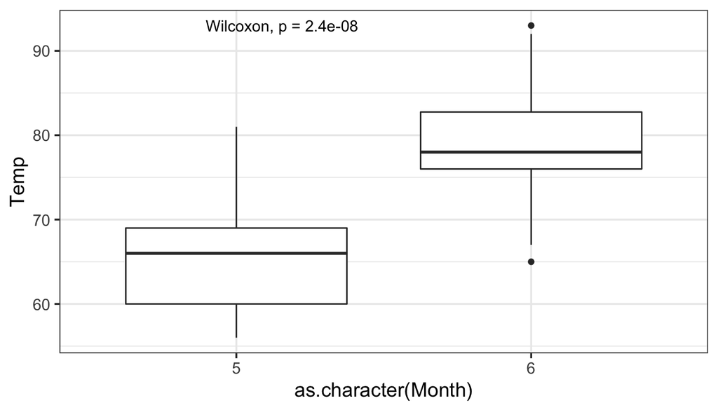

```r
ggplot(airquality[airquality$Month %in% c(5, 6), ], aes(x = as.character(Month),
    y = Temp)) + geom_boxplot() + stat_compare_means() + theme_bw(base_size = 14)
```

- You can change the type of test that is performed. For example, try updating `stat_compare_means()` to `stat_compare_means(method="t.test")`

We can visualize the spread of data in the different categories using other geometric objects. A **violin plot** is an extension of a box-plot that shows the kernel density distributions of the data points, in addition to the median value and spread.

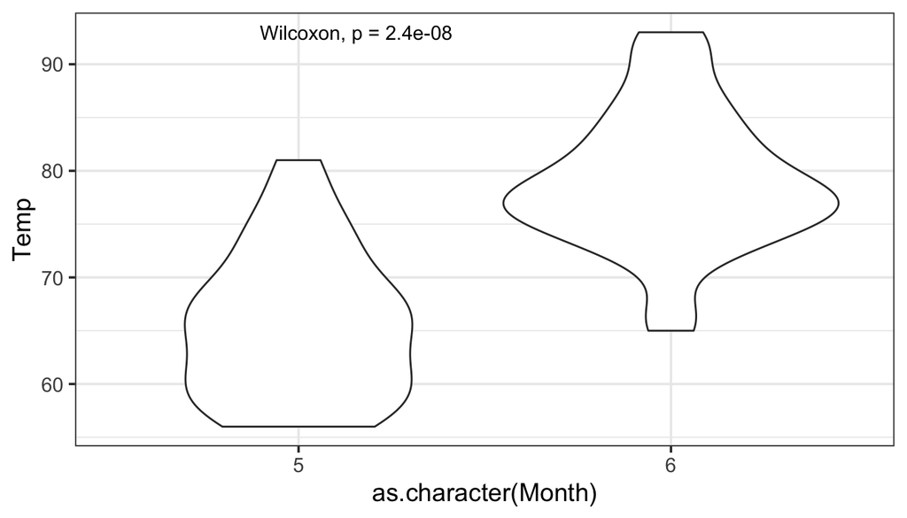

```r
ggplot(airquality[airquality$Month %in% c(5, 6), ], aes(x = as.character(Month),
    y = Temp)) + geom_violin() + stat_compare_means() + theme_bw(base_size = 14)
```

We can also extend the comparison to more than two groups. This, however, requires a bit of work. We first need to define the various pairwise comparisons we wish to perform. Subsequently we pass this list of comparisons to `stat_compare_means`.

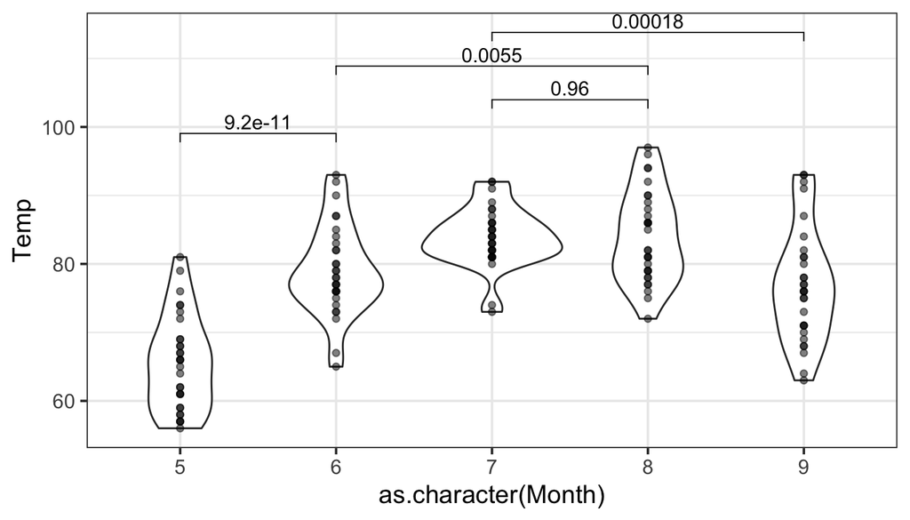

```r
my_comparisons <- list(c("5", "6"), c("7", "8"), c("6", "8"), c("7", "9"))
## Plot p-values for specified comparisons
ggplot(airquality, aes(x = as.character(Month), y = Temp)) + geom_violin() + geom_point(alpha = 0.5) +
    stat_compare_means(comparisons = my_comparisons, method = "t.test") + theme_bw(base_size = 14)
```

You can calculate the significance of difference in means between all groups relative to a reference, like so:

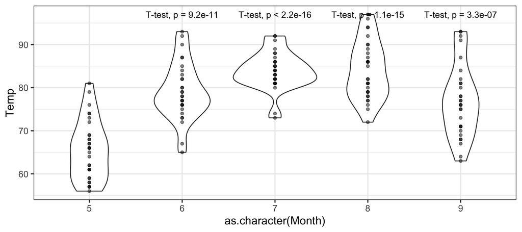

```r
ggplot(airquality, aes(x = as.character(Month), y = Temp)) + geom_violin() + geom_point(alpha = 0.5) +
    stat_compare_means(method = "t.test", ref.group = "5") + theme_bw(base_size = 14)
```

## ggpubr magic

ggpubr’s methods `theme_pubclean` and `theme_pubr` shift the focus of your plot to your data.

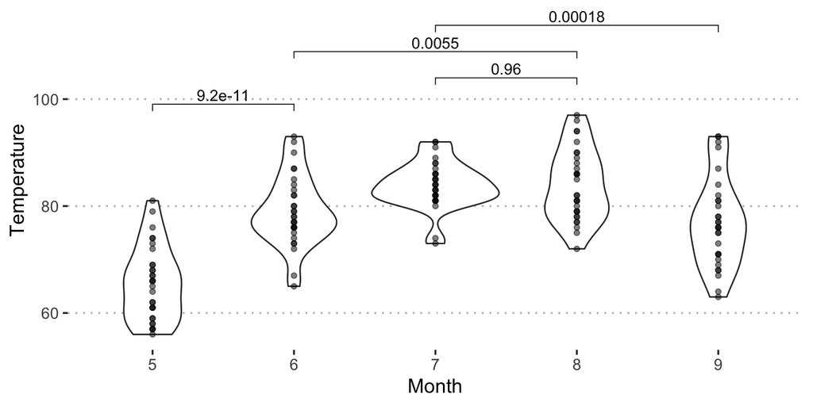

```r
my_comparisons <- list(c("5", "6"), c("7", "8"), c("6", "8"), c("7", "9"))

ggplot(airquality, aes(x = as.character(Month), y = Temp)) + geom_violin() + geom_point(alpha = 0.5) +
    stat_compare_means(comparisons = my_comparisons, method = "t.test") + labs(x = "Month",
    y = "Temperature") + theme_pubclean(base_size = 14)
```

# Additional Resources

[Understanding reshape2, wide and long formats](https://seananderson.ca/2013/10/19/reshape/)  
[Outlier detection with R](http://www.questionflow.org/2017/12/26/combined-outlier-detection-with-dplyr-and-ruler/)  
[Understanding Outliers and their relevance](https://towardsdatascience.com/a-brief-overview-of-outlier-detection-techniques-1e0b2c19e561) [Detailed lecture on data cleanup with R](https://cran.r-project.org/doc/contrib/de_Jonge+van_der_Loo-Introduction_to_data_cleaning_with_R.pdf)  
[Using ggpubr to calculate significance](http://www.sthda.com/english/articles/24-ggpubr-publication-ready-plots/76-add-p-values-and-significance-levels-to-ggplots/)

# Take-aways

1. Basic smell-tests on your data
2. Removing cases with missing data
3. Identifying outliers
4. Descriptive statistics
5. Using ggpubr to create publication-ready figures

# Extra

## Pairs plots for expression data

Given a few samples (observations) with a large number of genes (variables), we can quickly evaluate if certain samples are outliers, simply by comparing the pair-wise scatterplots for all the samples

```r
## We can also plot pairwise scatterplots
brca_df = data_merged[data_merged$cl_disease_detail %in% c("normal", "breast medullary carcinoma"),
    ]
## Reverse the melt step
brca_df_recast = dcast(brca_df[, c("Sample", "Gene", "Expression")], Sample ~ Gene)
rownames(brca_df_recast) = brca_df_recast$Sample
brca_df_recast$Sample <- NULL
## Remove the outlier gene
brca_df_recast = brca_df_recast[, !(colnames(brca_df_recast) %in% c("TSPAN6"))]
pairs(t(brca_df_recast), panel = function(...) smoothScatter(..., add = TRUE))
```

[output not shown]

## Filtering genes by average value or standard deviation

We firstly identify genes that vary within disease types. We will compare breast adenocarcinomas and breast ductal carcinomas.

```r
## Select the samples from the metadata dataframe
samples_brca = metadata_df[metadata_df$cl_disease_detail %in% c("breast adenocarcinoma",
    "breast ductal carcinoma"), ]
## Filter our dataframe based on this list
brca_cohorts_df = data_df_clean2[rownames(data_df_clean2) %in% samples_brca$cl_id,
    ]
### Compare this dataframe to what you get with the following command
brca_cohorts_testdf = data_df_clean2[samples_brca$cl_id, ]
```

We will do some filtering to identify the most variable genes. Bioconductor’s package [genefilter](http://bioconductor.org/packages/release/bioc/html/genefilter.html) also has some of these pre-implemented.

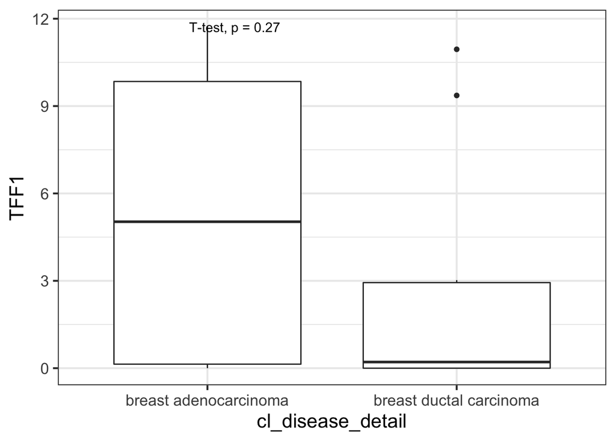

```r
# Calculate mean of each gene
avg_genes = sapply(brca_cohorts_df, mean)
# Calculate standard deviation of each gene
sd_genes = sapply(brca_cohorts_df, sd)
# Filter dataframe based on an SD threshold of your choosing
brca_cohorts_filt = brca_cohorts_df[, names(sd_genes[sd_genes == max(sd_genes)]),
    drop = FALSE]
brca_cohorts_filt$cl_id = rownames(brca_cohorts_filt)
brca_cohorts_filt = merge(brca_cohorts_filt, metadata_df)

ggplot(brca_cohorts_filt, aes(x = cl_disease_detail, y = TFF1)) + geom_boxplot() +
    theme_bw(base_size = 16) + stat_compare_means(method = "t.test")
```